# Bash Git GitHub

# BASH

## Basic Bash (Bourne Again SHel)

- `GNU` read “Gnoo” is an open source [operating system](https://www.gnu.org/home.en.html).
- Bash is the [GNU](https://www.gnu.org/software/bash/) Project’s shell

## The Command Line

- The **command line** is like the R command prompt: you insert code, hit enter, and then the computer executes your command.
- However, instead of inserting R code, you insert [Shell Script](https://en.wikipedia.org/wiki/Shell_script).
- In this class, we will use the command line primarily for two things:
  - Moving around your file system.
  - Running git commands.

### Other words for command line:

- Shell,
- terminal,
- command line interface (cli), and
- console.
  - These terms are technically slightly [different](https://askubuntu.com/questions/506510/what-is-the-difference-between-terminal-console-shell-and-command-line).
- There are many types of shells, each with their own scripting language. We will use the bash scripting language for this class.
- A huge difference between R and bash is how commands/functions are called.
  - R: `f(x, y = 1)`
  - Bash: `f x --y=1`
  - Arguments that are “flags” use only one dash, like `f x -g` would incorporate the `g` flag.

## BASH

In Bash, the usage of `-` and `--` helps distinguish between single-character flags (options) and multi-character flags (options with names).

### Single Dash (`-`) in Bash:

- A single dash (`-`) is used to denote a **short flag** (option), typically a single character.
- Multiple flags can be combined into one, making it more compact.

**Example**:

```bash
# Using the flag '-g' to specify a flag for the function
f x -g
```

Here, `-g` is a short flag. This could mean, for instance, that you’re passing a specific option to the function `f`.

### Examples

```bash
ls -a | head -n 5
```

```
.
..
.Rhistory
1_intro.qmd
2_update_r-rstudio_files
```

You can also combine short flags in a single command:

```bash
f x -g -h
```

This can also be written as:

```bash
f x -gh
```

Example:

```bash
ls -s -l | tail -n 5
```

```
  28 -rw-r--r-- 1 semiyari 1049089   26892 Jan 10  2024 practice_open_data.R
   1 -rw-r--r-- 1 semiyari 1049089      12 May 16 16:32 practice_readme.md
   0 drwxr-xr-x 1 semiyari 1049089       0 Aug 26  2024 raw.githubusercontent.com
   0 -rw-r--r-- 1 semiyari 1049089       0 Sep 17  2024 semiyari_hw.R
  12 -rw-r--r-- 1 semiyari 1049089    9408 Jan 16  2024 ssh_pat_2fa.qmd
```

### Double Dash (`--`) in Bash:

- The double dash (`--`) is used for **long options** (flags that have full names).
- These options are more readable and descriptive compared to the short options.

**Example**:

```bash
# Using the flag '--y' to specify a named flag
f x --y=1
```

In this case, `--y` is a long flag, and `=1` specifies a value associated with it.

**Explanation of each**:

1. `-g`: A short flag, often used for simpler options.
2. `--y=1`: A long flag, more descriptive and explicit with the assignment.

The practical example you’ll see is on git with

- `git status -s`
- `git status --short`

### Slicing output

- `sed` can be used for more precise slicing of lines.
- The following will print lines 70 through 80 from the output.

```bash
ls --help | sed -n '70,80p'
```

```
  -r, --reverse              reverse order while sorting
  -R, --recursive            list subdirectories recursively
  -s, --size                 print the allocated size of each file, in blocks
  -S                         sort by file size, largest first
      --sort=WORD            sort by WORD instead of name: none (-U), size (-S),
                               time (-t), version (-v), extension (-X)
      --time=WORD            change the default of using modification times;
                               access time (-u): atime, access, use;
                               change time (-c): ctime, status;
                               birth time: birth, creation;
                             with -l, WORD determines which time to show;
```

`sed`: Stands for **Stream Editor**.

## Installing Bash/Terminal

- If you are using Linux or Mac, then you can keep going. If you are using Windows, you need to first download and install git (and thus git bash) from here: http://git-scm.com/download/win. You might need to restart R Studio if you are already running it.

## Open up the terminal

- Windows: Open up the Git Bash app. It should look like this:

[figure not shown]

- Mac: On your Mac, do one of the following:
- Click the Launchpad icon in the Dock, type Terminal in the search field, then click Terminal.
- In the Finder , open the /Applications/Utilities folder, then double-click Terminal.
- Ubuntu: Do one of the following

Open the dash and search for “terminal”. Open up the terminal.

Use keyboard shortcut: Ctrl+Alt+T

- **The easiest way to open a terminal is within R Studio with “Tools > Terminal > New Terminal”**
- All commands get placed after the dollar sign.
  - Bash is type of shell. There are different type of shells available, such as Korn shell (ksh), C shell (csh), and Z shell (zsh).
  - You can determine your shell type using the `ps` command:

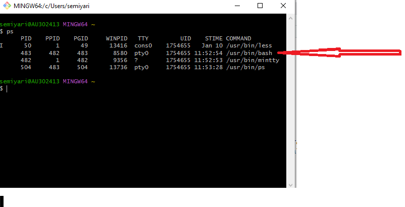

- The path before the dollar sign is the working directory of the terminal, **not** R’s working directory. It’s where the shell will reference all files from.
- The tilde “`~`” is shorthand for the “home directory”. Each computer has a home directory that is the “default directory”.

## Useful Commands:

- `date`: Displays the current date

```bash
date
```

```
Sat May 16 16:41:21 EDT 2026
```

- `pwd`: Print working directory. Show the current working directory. This is like `getwd()` in R.

```bash
    pwd
```

```
/c/Users/semiyari/Desktop/Personal/UNIV/AU/data_science/DATA613/AU-DATA613/Git
```

- `ls`: List the current files and folders in a directory.

```bash
    ls | head -n 3
```

```
1_intro.qmd
2_update_r-rstudio_files
2_update_r_rstudio.qmd
```

- `echo`: Prints a string of text, or value of a variable to the terminal.

```bash
echo "Hello World"
```

```
Hello World
```

- `man` command in Linux is used to display the user manual of any command that we can run on the terminal.

```bash
man ls
```

```
/c/PROGRA~1/Git/usr/bin/bash: line 1: man: command not found
```

- If you are using Windows with a Bash emulator like Git Bash, the man command may not be available. You can use online resources or alternative commands like `--help`. You can scroll through this page using the up and down arrows.

```bash
ls --help | head -n 6
```

```
Usage: ls [OPTION]... [FILE]...
List information about the FILEs (the current directory by default).
Sort entries alphabetically if none of -cftuvSUX nor --sort is specified.

Mandatory arguments to long options are mandatory for short options too.
  -a, --all                  do not ignore entries starting with .
```

- Comments in bash starts with a `#` in bash scripting. This means that any line that begins with a `#`is a comment and will be ignored by the interpreter.

```bash
echo "Comments in bash starts with a # in bash scripting." # This line that begins with a `# `is a comment and will be ignored
```

```
Comments in bash starts with a # in bash scripting.
```

- `cd`: Change directories. This is like `setwd()` in R. As when we specified paths in R, using two periods mean “move back a folder”.

```bash
    pwd
```

```
/c/Users/semiyari/Desktop/Personal/UNIV/AU/data_science/DATA613/AU-DATA613/Git
```

- The `cd../` tells move back a folder

```bash
    cd ../
    pwd
```

```
/c/Users/semiyari/Desktop/Personal/UNIV/AU/data_science/DATA613/AU-DATA613
```

- If you use `cd` without specifying a folder to move to, it will move the working directory to the home directory.

```bash
    cd
    pwd
```

```
/c/Users/semiyari/Documents
```

```bash
    cd c:Users/semiyari/Desktop/Personal/AU/DATA613/Spring24/Week1
    pwd
```

```
/c/PROGRA~1/Git/usr/bin/bash: line 1: cd: c:Users/semiyari/Desktop/Personal/AU/DATA613/Spring24/Week1: No such file or directory
/c/Users/semiyari/Desktop/Personal/UNIV/AU/data_science/DATA613/AU-DATA613/Git
```

### Other commands.

```bash
ls | head -n 6
```

```
1_intro.qmd
2_update_r-rstudio_files
2_update_r_rstudio.qmd
3_basic_bash.qmd
4_vcs_git.qmd
5_git_setup.qmd
```

- `cp`: Copy a file.

```bash
    cp Exercise-Bash.qmd copy_exercise_bash.qmd
    ls | head -n 6
```

```
1_intro.qmd
2_update_r-rstudio_files
2_update_r_rstudio.qmd
3_basic_bash.qmd
4_vcs_git.qmd
5_git_setup.qmd
```

- `mv`: Move/rename a file.

```bash
    mv copy_exercise_bash.qmd rename_exercise_bash.qmd
    ls | head -n 6
```

```
1_intro.qmd
2_update_r-rstudio_files
2_update_r_rstudio.qmd
3_basic_bash.qmd
4_vcs_git.qmd
5_git_setup.qmd
```

- `rm`: Remove a file.

```bash
    rm rename_exercise_bash.qmd copy_exercise_bash.qmd
    ls | head -n 6
```

```
rm: cannot remove 'copy_exercise_bash.qmd': No such file or directory
1_intro.qmd
2_update_r-rstudio_files
2_update_r_rstudio.qmd
3_basic_bash.qmd
4_vcs_git.qmd
5_git_setup.qmd
```

- `mkdir`: Make a directory/folder.

```bash
    mkdir tempdir
    ls
```

- `rmdir`: Remove a directory/folder.

```bash
    rmdir tempdir
    ls
```

- Play [Terminus](http://web.mit.edu/mprat/Public/web/Terminus/Web/main.html) for more practice.

## How to move a file from one folder to another using a Bash command, you can use the `mv`

```bash
mv /path/to/source/file /path/to/destination/folder/
```

## Example

let us add a file in our directory folder, I pick a name that show on type like `0_aaa.txt`

```bash
echo "Hi There" >> 0_aaa.txt
```

Now check your folder to see it is there

```bash
ls
```

_ Let’s print what is inside of the file

```bash
cat 0_aaa.txt
```

```
Hi There
```

- Now lets move it to t two folder back

```bash
mv ./0_aaa.txt ../..
```

- Now check if it is still in our directory. It should not be there, because we moved it

```bash
ls
```

- Two folder back

```bash
ls ../..
```

- Now let’s put it back where it was before. So we have to move back two folder to pick it up

```bash
mv ../../0_aaa.txt ./
```

- check if it is in our directory

```bash
ls
```

- Now remove the file

```bash
rm ./0_aaa.txt
```

- Check if it has been removed

```bash
ls
```

### A few shortcut:

1. Type `explorer` in Bash/Terminal to open “File Explorer”. Or on keyboard hold window button and click `E`
2. Type a few letters on Terminal/Bash and then click on `tab` button to get the possible match. (Once for terminal-Twice for Bash)
3. To interrupt the current command press `CTRL+C` .
4. Type `clear` to clear the Terminal/Bash page
5. Type `exit` and press ENTER
6. Use `alt+shift+R` to open terminal-pane
- **What is difference between `>>` and `>` in Bash/Terminal?**

This symbol `>` overwrites the file if it exists or creates it if it doesn’t exist.

```bash
echo "The `>` overwrites the file if it exists or creates it if it doesn't exist." > file1.txt
```

```
/c/PROGRA~1/Git/usr/bin/bash: command substitution: line 1: syntax error near unexpected token `newline'
/c/PROGRA~1/Git/usr/bin/bash: command substitution: line 1: `>'
```

```bash
cat file1.txt
```

```
The  overwrites the file if it exists or creates it if it doesn't exist.
```

```bash
echo "This will overwrite the file and what we had before has been replaced with this line" > file1.txt
```

```bash
cat file1.txt
```

```
This will overwrite the file and what we had before has been replaced with this line
```

This `>>` is used to append to a file.

```bash
echo "This symbol \">>\" is used to append to a file." >> file1.txt
```

if you run `cat file1.txt` you will see both lines are in file1.txt

```bash
cat file1.txt
```

```
This will overwrite the file and what we had before has been replaced with this line
This symbol ">>" is used to append to a file.
```

# Git

- Git is the most popular `version conrol` system in the world. A vesrion control system records the changes that made to our code over time in a special database called `repository`. We can look at our project history and see who has made what changes when and why. If we made a mistake on something we can easily revert our project back to an earlier state.  
  In summary, with version control system we can track history and work together.
- Git is free, open source, super fast, and scalable. Operation such as `branching` and `merging` are slow in other version control system like `subversion` or `tfs`But they are very fast in Git.
- Git is everywhere, almost every job description (programming related) mentions Git.
- To check if you have installed it:
  - Go to `Terminal` pane in Rstudio (or open in new terminal with `Tools` > `Terminal` > `New Terminal`) then type

```
    git version
```

```
or
```

```
    git --version
```

```
If the version number is lower than 2.43.0 or if the response is blank or something like
```

```
    git: command not found
```

```
then you need to install it.
```

## Install Git

- Windows:
  - Click on https://git-scm.com/download/win
  - Click `Download` (Standalone Installer - 64 bit) .When it is finished open the “Explore” window ( press the Windows logo key + E on your keyboard) and go to download folder and open it there.
  - Once its open we click “Next” and we accept the default options until we get the install page and then click “install”.
  - I t takes a while to install and once it is done we can click “Finish”.

Let us check if “Bash” is installed. + Click on Windows menu button and choose all apps, then scroll down to the “G,s” and expand “Git” Options and click “Git Bash” option.

[figure not shown]

- Type in BASH `git --version` it will tell you the version of your Git.
- Mac:
  - Option 1: Open the terminal and type

```
    git --version
```

[output not shown]

- Linux:
  - Open the terminal and type

  ```
  git --version
  ```

  If git is missing install is using your package manager. E.g. by running

  ```
  sudo apt-get install git
  ```

  In the terminal.

### **Question :If you have installed Bash what version do you have?**

```
bash --version
```

### **Question :If you have installed Git what version do you have?**

- Type in BASH/Terminal `git --version` it will tell you the version of your Git.

```
git --version
```

# Create GitHub

- Git is a *version control system (VSM)*, GitHub is a *website* that hosts git repositories. (so on your resume, say that you know git, not GitHub).
- *How to open an account in github?*
  - Step 1: Go to github.com, and then select Sign up.
  - Step 2: Enter your *email* address.
  - Step 3: Create a *password* for your new GitHub account and then click *continue*.
  - Step 4: Verify your account by solving a *puzzle*. Then select the *Create account* button.
  - Step 5: GitHub sends a *launch code* to your email address. Type that launch code in the Enter code dialog, and then press *Enter*.
  - Step 6: GitHub asks you some questions. Then choose the *Free account*, select the *Skip personalization button*.

# Authentication

- GitHub now requires you to use either [Personal Access Tokens](https://docs.github.com/en/authentication/keeping-your-account-and-data-secure/creating-a-personal-access-token) or [SSH Keys](https://docs.github.com/en/authentication/connecting-to-github-with-ssh) for interfacing. For this class, we’ll use SSH Keys since its implementation is slightly easier.
- Open up Tools > Global Options… > Git/SVN.
- If you do not have an SSH key pair, then click on “Create RSA(SSH) Key…”

[figure not shown]

You may receive a note indicating similar to

Generating public/private ed25519 key pair. Your identification has been saved in C:/Users/semiyari/.ssh/id_ed25519. Your public key has been saved in C:/Users/semiyari/.ssh/id_ed25519.pub.

- Click on “View public key”

[figure not shown]

- Copy the entire text that shows up. This is your public key.

### Add Public Key to GitHub

1. On GitHub, in the upper right corner, click on your profile photo and click on “Settings”

[figure not shown]

2. On the left sidebar, click on “SSH and GPG keys”

[figure not shown]

3. Click on “New SSH key”

[figure not shown]

4. In the title field, choose a descriptive title, like “Personal Laptop”.

5. Paste your key into the “Key” field.

[figure not shown]

6. Click “Add SSH key” and confirm your GitHub password.

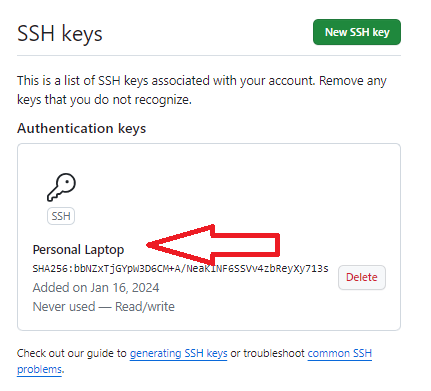

### Test to see if it worked

1. Enter the following in the terminal:

`ssh -T git@github.com`

2. Type “yes” if prompted to continue connecting.
3. You are successful if you see something like

`Hi hamidsem! You've successfully authenticated, but GitHub does not provide shell access.`

# Basic Git

- A **repository** (or repo, for short) is a collection of files (in a folder and its subfolders) that are together under version control. In data analysis, each repository is typically one project (like a data analysis, a homework, or a collection of code that performs a similar task).
- The way git works (graphic from Mark Lodato):

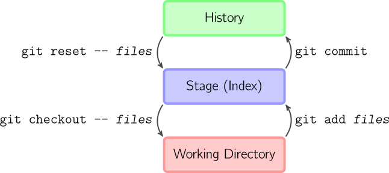

- **Working Directory**: To git, this means the current versions of the files. Changes to files that you haven’t recorded only exist in the working directory and are not yet saved in the history.
- **Stage**: Files that are scheduled to be committed to the history, but not yet committed. Only files in the stage will be committed to the history.
- **History**: The timeline of snapshots of files. You commit a file to the history and then, even if you modify it later, you can always go back to that same file version.
- We’ll focus on the right-hand-side of this diagram where your workflow is typically:
  1. Modify files in your working directory until you want a snapshot.
  2. Add these modified files to the staging area.
  3. Commit staged files to history, where they will be kept forever.
- The left-hand side of the diagram is used when you want to undo mistakes.
- All git commands begin with `git` followed immediately by an argument for the type of command you want to execute.
- For the right-hand-side of the diagram, the following are the useful git commands:
  - `git init`: Initialize a git repository. *Only do this once per project*.
  - `git status`: Show which files are staged in your working directory, and which are modified but not staged.
  - `git add`: Add modified files from your working directory to the stage.
  - `git diff`: Look at how files in the working directory have been modified.
  - `git diff --staged`: Look at how files in the stage have been modified.
  - `git commit -m "[descriptive message]"`: commit your staged content as a new commit snapshot.

### How to use Git?

- Command line: We can use Git on the command line. Open a termianl or command window to execuate git commands. This the fastest sometimes easiest way to get the job done.
- Code editors & IDEs (or Integrated Development Environment): Most code editors and IDEs have built-in support for basic Git features.
- Graphical User Interfaces: There are GUIs specifically made for using Git. You can find the complete list of these tools for different platforms on the Git website. Click [here](https://git-scm.com/downloads/guis). GUI tools are not always available. GuI tools have somelimitations. You might connect to a server remotly and you may not have permission to install GUI tool. So to my opinion it is better to use commond line. There are many people use both GUI tool and command line.
- A code editor is a text editor that has some features that make writing code easier. For instance, code editors will automatically highlight words based on syntax and will automatically indent lines of code correctly. An IDE is usually more complex than a simple text or code editor. It has more features, it takes time to learn, but in the end is more powerful. It is a piece of software that allows developers to create, modify, and debug code easily. A code editor doesn’t have the debugging and auto-complete features that an IDE has. Atom is a code editor and Rstudio is an IDE.

### Default editor

If you do not set this on mac. Git is going to use (by default) `vim` which many people doesn’t like it. You may want to use [visual studio code](https://code.visualstudio.com/). **You don’t have to use Visual Code, You may use another Editors.** I am going to use `VSCode` or Visual Studio Code. To add the default editor `git config --global core.editor "code --wait"`.  
Why wait? With the wait flag we tell the terminal window to wait until we close the new `VSCode`.  
All these configuration setting are store in a text file.  
We can edit that file using our default editor. Which in this case is `VSCode`.  
So we can type `git config --global -e`  
This will open our default editor to edit all the global setting. If you type the code, you will see the full path on top, which mine is `users/semiyari` the name of this file is “.gitconfig”. If you look at the VScode you will see in this file we have different sections

[figure not shown]

[figure not shown]

- So we have to close the VScode

[figure not shown]

- Handle end of lines: This is a very important setting that lots of people miss.

- On Windows end of lines are marked with two special characters `\r` and `\n`.
- Carrige Return `\r`: It means that the curser should **go back to the beginning of the line**.
- Line feed `\n`: It means that the curser must **go to the next line**
- On Mac and Linux systems, the end of lines are indicated with - Line feed `\n`

  That means if we don’t handle end of lines properly we are going to run into some issues down the road.
- **Window:** `git config --global core.autocrlf true` (`crlf` is short for Carriage Return Line Fit)
- **Mac or Linux:** `git config --global core.autocrlf input`

### You may use different editor

- Choose your favorite editor to be your default
  - Nano (a simple text editor):

  ```
  `git config --global core.editor "nano -w"`
  ```

  - Notepad (Windows only):

  ```
  `git config --global core.editor "c:/Windows/System32/notepad.exe"`
  ```

  - Emacs (for the brave) if it is already installed:

  ```
  `git config --global core.editor "emacs"`
  ```

  - [Atom](https://www.youtube.com/watch?v=KA9xvKQXXzQ)
1. Open https://atom.io/ in your browser.
2. Click the ‘Download’ button to download the Atom installer.
3. Once Downloaded, run the installer to install Atom.

### **How should I check what Text Editor I have in my computer?**

-1. Simply click your Windows Start button and then go to All Apps and scroll until you locate your Edtitor.

[figure not shown]

- 2. Type the following command in your terminal

```
git config --global -e
```

[figure not shown]

If you want to change the editor, you can use:

```
git config --global core.editor <editor>
```

The editor “Nano” is installed by default. If you want to use this one you need to write

```
git config --global core.editor "nano"
```

Then type

```
git config --global -e
```

To exit you just need to hold `ctrl` and click x, `ctrl + x`

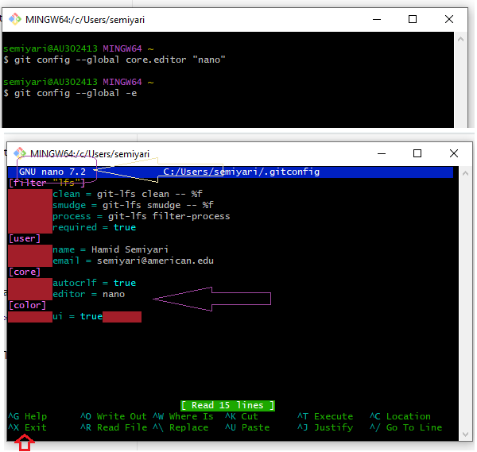

- **Question: What is difference between “Text Editor” and “Integrated Development Environment” or “IDE”?**

A code editor is a text editor that has some features that make writing code easier. For instance, code editors will automatically highlight words based on syntax and will automatically indent lines of code correctly. An IDE is usually more complex than a simple text or code editor. It has more features, it takes time to learn, but in the end is more powerful. It is a piece of software that allows developers to creat, modify, and debug code easily. A code editor doesn’t have the debugging and autocomplete features that an IDE has. Atom is a code editor and Rstudio is an IDE.

- **Question: How to change your default text editor for git (and avoid vim)**
  - To find what your text editor is type the following in your terminal

```bash
git config --global core.editor
```

- If you see `code --wait`, that means “VSCode”
- If you are an apple user and have not selected your code editor, then by default you have `vim`.
- If you want to learn how to change your code editor click [here](https://dev.to/biancapower/how-to-change-your-default-text-editor-for-git-and-avoid-vim-fk0)

### Getting Help

- How to get help about git commands - If you want to learn more about config commands. Just google “git config”, then you can be directed to the page git-scm.com/docs/git-config - We can also get the same information from the terminal window, just type `git config --help` - If you type `git config -h` It gives us a short summary of its commands and options

# Create a Repository on GitHub

- On your GitHub homepage, click on “New”
  - Repository name is “test”.
  - The repo is set to be “Private”
  - You check “Add a README File”

## Cloning

- We use “SSH” it is easier to work with than “PAT”
  - Make sure to copy the link
  - Run `git clone <SSH>` on your BASH/Terminal

## BASH/ Terminal

- Type `ls` to make sure the clone repository is in your directory
- Go to your new Repo by `cd test`
  - `test` is the name of the repository that you created on your GitHub.

### Working with Remote

- To be able to collaborate on any Git project, you need to know how to manage your remote repositories. Remote repositories are versions of your project that are hosted on the Internet or network somewhere.
  - To see which remote servers you have configured, you can run the `git remote` command. If you’ve “cloned” your repository, you should at least see `origin.`
  - `git remote -v` shows you the URLs that Git has stored for the shortname to be used when reading and writing to that remote

# Recall

- Add a file to your project folder(`test`). For instance:
- `echo "This file is just for practice" >> file.txt`
- Use `git status` to see what files, git is tracking and which are untracked.
- Stage the file. `git add file.txt`
  - If you get “warning: in the working copy of ‘file.txt’, LF will be replaced by CRLF the next time Git touches it.”

## **Line Endings in Different Operating Systems**

    `git config --global core.autocrlf input`

## **CRLF (Carriage Return + Line Feed):** Used as a newline character in Windows.

    - `{git config --global core.autocrlf true}`
- Commit the file. `git commit -m "Add one file"`
- Run `git status`. What do you see?
- Modify the file: `echo "Override the file" > file.txt` Now we want to see the changes in this file. So we use `diff` function.

## `Diff` function

- Show changes between commits, commit and working tree/directory
- `git diff [<options>] [--] [<path>…]` This form is to view the changes you made relative to the index (staging area for the next commit). It doesn’t show all chnges since your last commit.
- Run `git diff`. What do you see? You should see the line that was deleted in red and the one that was added in green.
- Run `git diff --staged`. It shows what you have staged and which will go into your next commit. Did we have get anything as an output?
  - *remember, When you run `git diff --staged`, it compares the changes between the last commit and the changes that are currently staged.* Now let us stage the change. Run `git add file.txt`
  - Run again `git diff --staged`. What do you get in output?
  - Run `git diff` what do you in output? *Recall: The `git diff` command shows the changes between the working directory and the last commit, that hasn’t been staged yet.*

### A Quick note

- In a more realistic `diff`, you would see a header like
  - `@@ -34, 6 +34, 8 @@`
- It indicates that:
  - 6 lines have been extracted starting from line number 34.
  - 8 lines have been added starting at line 34.
- Now stage and commit the “file.txt”. Run `git commit -a -m "Override the file.txt"`
- Run `git log --follow file.txt`. This command shows the commit history of the file.

### `git commit -a -m "<MESSAGE>"`

The command `git commit -a -m "<MESSAGE>"` combines the effects of `git add` and `git commit`, but skips the explicit `git add` step. It stages changes to tracked files, meaning it only works for files that Git is already tracking. However, it does not include untracked (new) files, which must first be added to the staging area using `git add`. Once a file is tracked, subsequent modifications can be committed without explicitly staging the file again using `git add`. This approach is not recommended unless you fully understand its implications.

### Retrieve Old Vesrions

- We use SHA value (Checksum)
- run `git log` or `git log --follow FILENAME`
- Go to commit that you want to retrieve and pick some “SHA_value”
- Now type `git checkout SHA_value -- FILENAME`

### Example:

- Type `cat file.txt` to see what is inside of file.txt. It will return for me “Override the file”
- To see its previous version we select the SHA value for the previous commit. `git checkout 2a276481 -- file.txt` **Note: Your SHA would be different than this.**
  - Run `cat file.txt` will return for me “This file is just for practice”
  - Can you retrieve the final version of the file? The last commit of this file?

## Status

- Use `git status` to see what files, git is tracking and which are untracked.
- Edit the README.md file to include your name
- Add a file to your project folder.
  - Any file from your other folders. Let’s call it “YOURFILE”
- check status
  - What do you see? You should have two red files.
  1. modified: README.md
  2. your added file. “YOURFILE”
- Run, `git status -s` or `git status --short`

### Short Status

- New files that aren’t tracked have a `??` next to them, new files that have been added to the staging area have an `A`, modified files have an `M` and so on.
- There are two columns to the output.
  - The left-hand column indicates the status of the staging area and the right-hand column indicates the status of the working tree.

## Staging

- add README.md to staging area. Run `git add README.md`
- Run `git status --short`. What do you see?
- Now move “YOURFILE” to staging area
- Run `git status -s`. What do you see?

## History

### Commit the files

Run `git commit -m "Last commit"`. We will push the files in the next step.

- Run `git log` to get your meta data.
  - Do you see all your commits?
  - How about the author?
  - What else do you see?

## Amend

- `--amend` One of the common undos takes place when you commit too early and possibly forget to add some files, or you mess up your commit message.

### Case 1:

If you messed up the commit, then you can do either of the following 1. `git commit --amend` The default text editor will be opened up in which you can replace the message from your older commit.

```
2.  `git commit --amend -m "Your Message"` enter the your correct message.
```

- You have noticed that you made a mistake in your last commit. Run `git commit --amend -m "Modify README and ADD a new file."` **Note, we should do this in two separate commits**
- Run `git log`, the last commit has changed. How about the “Checksum” does it have changed? Explain it?

## Case 2:

- your last commit is missing a crucial file. Without it, your project worth nothing
- Add the missing file.
- Stage the changes:

```
git add <missing_file>
```

- Now, amend the last commit. We use `git commit --amend` or `git commit --amend --no-edit`

This command will change the files in your last commit. It will not change the message associated with the commit because we have not used the `-m` flag.

- You want to add missing file. I have file.txt in my directory and I know it was my missing file.
  - First, run `git add file.txt` then
  - use `git commit --amend --no-edit`

## Push

The `-u` or `--set-upstream` option is useful for the first push of a new branch. After using this command, you can simply use `git push` or `git pull` without specifying the branch name, and Git will automatically use the upstream branch.

Run `git push origin main` You should get something similar to:

```
$ git push origin main
Enumerating objects: 6, done.
Counting objects: 100% (6/6), done.
Delta compression using up to 8 threads
Compressing objects: 100% (3/3), done.
Writing objects: 100% (4/4), 91.40 KiB | 13.06 MiB/s, done.
Total 4 (delta 1), reused 0 (delta 0), pack-reused 0
remote: Resolving deltas: 100% (1/1), completed with 1 local object.
To github.com:semiyarih/Spring24.git
   8023768..11792a6  main -> main
```

## Pull and Fetch

- Both are used to update a local Repository with changes from a remote Repository. The Key difference is:
  - `git fetch` only downloads the changes from the remote repository, while `git pull` downloads the changes and “merges” them into the current branch.

### Example:

- Upload a file to your GitHub via browser. How? See “Add to a repository via a browser” in “8b_git_push.html”
- I added the file `.gitignore` to my remote repository on GitHub via browser. If you remembered we made this file in our previous lesson. if you don’t have it then I recommend you to read “IGNORING FILES” in “7_git_basic.html”
- Now you should have the `.gitignore` in your GitHub. But you do not have it in your project folder. So, you need to update your project directory.

### FETCH VS PULL

- Check your working directory to confirm `.gitignore` is not there. Run `ls -a`.
- Fetch:
  - Run `git fetch` or `git fetch origin` this command download all changes from the remote repository named `origin`
  - Run `git log` It shows all commit that you have made in your local machine
  - Run `git log origin` to see all the commit that you have made including in Github.

Run `ls -a` it shows `.gitignore` is not there and your directory is not updated yet.

- PULL:
  - run `git pull origin main` this command download all changes from the remote repository named `origin` and merged them into your local `main` branch.

Run `ls -a` it shows `.gitignore` is there and your directory is updated.